# SAGs global abundance

22.11.2016

A total amount of 1062 SAGs (GEN: 868 out of 903; ICM: 31 out of 40; BLA: 163 out of 169) contain the sequence of the forward primer 1389F for the V9 region (5’- TTGTACACACCGCCC -3’). None of the 1062 SAGs contains the complete sequence of the reverse primer 1510R (5’- CCTTCYGCAGGTTCACCTAC -3’) - most of the 18S rDNA SAGs miss the last ~5 bp of the V9 region.

We blasted the V9 sequences of SAGs and MMETSPs on Tara swarms and we selected the hits showing a coverage >80% and a similarity =100%.

# 1) Piconano- & nano- size fractions

No. of GEN SAGs aligned with a swarm:

```
## [1] 546
```

No. of ICM SAGs aligned with a swarm:

```
## [1] 16
```

No. of BLA SAGs aligned with a swarm:

```
## [1] 99
```

No. of MMETSP V9 sequences aligned with a swarm:

```
## [1] 197
```

Summary:

GENOSCOPE:  
- 903 SAGs.  
- 868 SAGs contain the V9 sequence.  
- 546 SAGs could be aligned with some swarm (100% identity, >80% coverage).  
ICM:  
- 40 SAGs.  
- 31 SAGs contain the V9 sequence.  
- 16 SAGs could be aligned with some swarm (100% identity, >80% coverage).  
BLANES:  
- 169 SAGs.  
- 163 SAGs contain the V9 sequence.  
- 99 SAGs could be aligned with some swarm (100% identity, >80% coverage).  
MMETSP:  
- 537 V9 sequences.  
- 197 V9 sequences could be aligned with some swarm (100% identity, >80% coverage).

## 1.1) Rank abundance curves

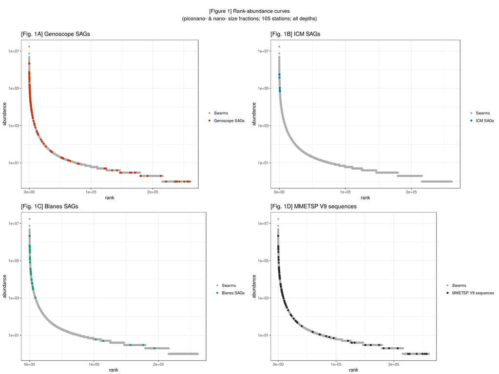

## 1.2) Occurrence in Tara Oceans stations

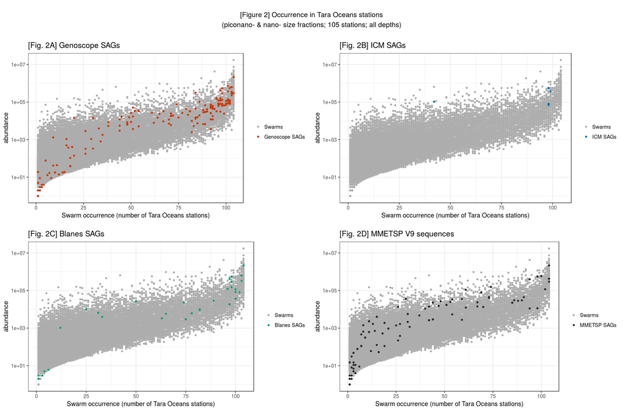

## 1.3) Abundance table

|  | SAG_id | ident.% | identity | SAG_lth | swm_lth | coverage | abund | rank | dataset | no_of_stations | swarm_taxogroup | taxonomic_classif |
| --- | --- | --- | --- | --- | --- | --- | --- | --- | --- | --- | --- | --- |
| 1 | AA534_B13_PELA_P_23_D | a68daf3e2b565f9065c1ca34bf8e90bf | 100 | 123 | 130 | 94.615 | 2154733 | 12 | Genoscope | 104 | Pelagophyceae | Stramenopiles_Pelagophytes_Pelagomonas-calceolata-gene-for-18S-small-subunit-ribosomal-RNA-partial-sequence-isolate:-from-Globigerinella-siphonifera-PF5 |
| 2 | AA534_C06_PRYM_P_23_D | 96ba4c7ae236906870f016a7e6fe8612 | 100 | 125 | 133 | 93.985 | 115932 | 659 | Genoscope | 100 | ? undetermined eukaryotes * | Hacrobia_Prymnesiophyceae_Chrysochromulina-scutellum-18S-rRNA-gene-strain-UIO46---G7- |
| 3 | AA534_D08_PELA_P_23_D | a68daf3e2b565f9065c1ca34bf8e90bf | 100 | 118 | 130 | 90.769 | 2154733 | 13 | Genoscope | 104 | Pelagophyceae | Stramenopiles_Pelagophytes_Pelagomonas-calceolata-gene-for-18S-small-subunit-ribosomal-RNA-partial-sequence-isolate:-from-Globigerinella-siphonifera-PF5 |
| 4 | AA534_D23_PELA_P_23_D | a68daf3e2b565f9065c1ca34bf8e90bf | 100 | 119 | 130 | 91.538 | 2154733 | 14 | Genoscope | 104 | Pelagophyceae | Stramenopiles_Pelagophytes_Pelagomonas-calceolata-gene-for-18S-small-subunit-ribosomal-RNA-partial-sequence-isolate:-from-Globigerinella-siphonifera-PF5 |
| 5 | AA534_F13_OCHN2_P_23_D | 7e0aee26a047576f96da68ccefd9634e | 100 | 124 | 130 | 95.385 | 103246 | 708 | Genoscope | 86 | ? a blaster | Stramenopiles_MOCH-2_Florenciella-parvula-18S-ribosomal-RNA-gene-partial-sequence |
| 6 | AA534_F21_PELA_P_23_D | a68daf3e2b565f9065c1ca34bf8e90bf | 100 | 124 | 130 | 95.385 | 2154733 | 15 | Genoscope | 104 | Pelagophyceae | Stramenopiles_Pelagophytes_Pelagomonas-calceolata-gene-for-18S-small-subunit-ribosomal-RNA-partial-sequence-isolate:-from-Globigerinella-siphonifera-PF5 |
| 7 | AA534_I02_PELA_P_23_D | a68daf3e2b565f9065c1ca34bf8e90bf | 100 | 124 | 130 | 95.385 | 2154733 | 16 | Genoscope | 104 | Pelagophyceae | Stramenopiles_Pelagophytes_Pelagomonas-calceolata-gene-for-18S-small-subunit-ribosomal-RNA-partial-sequence-isolate:-from-Globigerinella-siphonifera-PF5 |
| 8 | AA534_I03_PELA_P_23_D | a68daf3e2b565f9065c1ca34bf8e90bf | 100 | 124 | 130 | 95.385 | 2154733 | 17 | Genoscope | 104 | Pelagophyceae | Stramenopiles_Pelagophytes_Pelagomonas-calceolata-gene-for-18S-small-subunit-ribosomal-RNA-partial-sequence-isolate:-from-Globigerinella-siphonifera-PF5 |
| 9 | AA534_J20_OCHN2_P_23_D | 62c06110ec7b1230b27006130f26e6ef | 100 | 123 | 130 | 94.615 | 284963 | 390 | Genoscope | 98 | ? a blaster | Stramenopiles_MOCH-2_Haramonas-viridis-gene-for-18S-ribosomal-RNA-partial-sequence-strain:-TKB-314 |
| 10 | AA534_L02_PRAB_P_23_D | 9c745abb61c01676fc8bc4d8dd5bf060 | 100 | 125 | 132 | 94.697 | 543479 | 173 | Genoscope | 98 | Mamiellophyceae | Archaeplastida_Mamiellophyceae_Bathycoccus-prasinos-isolate-CCMP1898-18S-ribosomal-RNA-gene-partial-sequence-internal-transcribed-spacer-1-5.8S-ribosomal-RNA-gene-and-internal-transcribed-spacer-2-com… |

[output cut: 848 more lines]